Saltar para o conteúdo principal

# Boletim Macro Semanal

Data de referência: 2026-11-23

## Quadro

Quadro-resumo dos indicadores acompanhados nesta semana. Data de referência do boletim: 2026-11-23. Cada indicador traz o seu próprio mês ou dia de referência: o IPCA é de 10/2026 e o IBC-Br é de 09/2026.

| Indicador | Último valor | Var. mês | Var. 12 meses |
| --- | --- | --- | --- |
| IPCA (10/2026) | 0,14% | 0,14% | 4,63% |
| Câmbio R$/US$ (23/11/2026) | R$ 5,97 | 18,52% | 10,77% |
| Selic meta (23/11/2026; % a.a.; variações em p.p.) | 13,75% a.a. | 0,00 p.p. | -1,25 p.p. |
| IBC-Br (09/2026) | 109,43 (índice, original, SGS 24363) | -0,25% (SA, SGS 24364) | 1,43% (original, SGS 24363) |

## Inflação

O Índice Nacional de Preços ao Consumidor Amplo (IPCA), apurado pelo IBGE e coletado via SGS 433, registrou variação de 0,14% em 10/2026, o mês mais recente disponível para a série. No acumulado do ano, a alta é de 4,10%; em doze meses, 4,63%.

IPCA acumulado em 12 meses: **4,63%** (10/2026). O índice está **acima do teto** da banda de 1,50% a 4,50%, pelo 2º mês consecutivo. São 6 meses seguidos fora que caracterizam descumprimento e obrigam o presidente do BC a enviar carta aberta ao Ministro da Fazenda. Desde a entrada do regime contínuo, em jan/2025, foram 14 dos 22 meses fora da banda, com sequência máxima de 10 meses consecutivos.

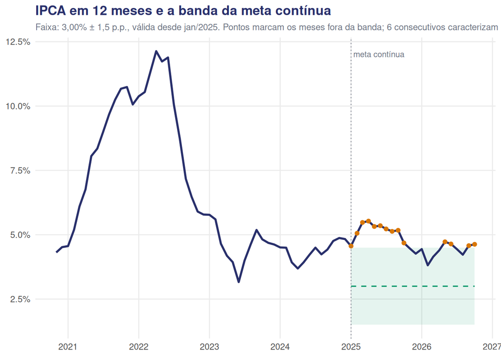

IPCA acumulado em 12 meses e banda da meta contínua (3,00% ± 1,5 p.p., válida desde jan/2025). Fonte: IBGE, via SGS 433.

## Câmbio e juros

### Taxa de câmbio

A taxa de câmbio R$/US$ (SGS 1), cotação de fechamento, está em R$ 5,97 na referência de 23/11/2026. No mês, a cotação subiu 18,52%, sentido que corresponde à desvalorização do Real. O intervalo vai de R$ 5,04 (23/10/2026) a R$ 5,97 (23/11/2026). Ele inclui uma alta de 9,19% entre 23/10/2026 (R$ 5,0377) e 26/10/2026 (R$ 5,5007), variação que ocorre dentro da alta mensal de 18,52%. Os dados da série mostram o movimento, mas não informam sua causa, e este boletim não a atribui. No acumulado do ano e em doze meses o sentido é o mesmo: alta de 8,51% e de 10,77%, respectivamente.

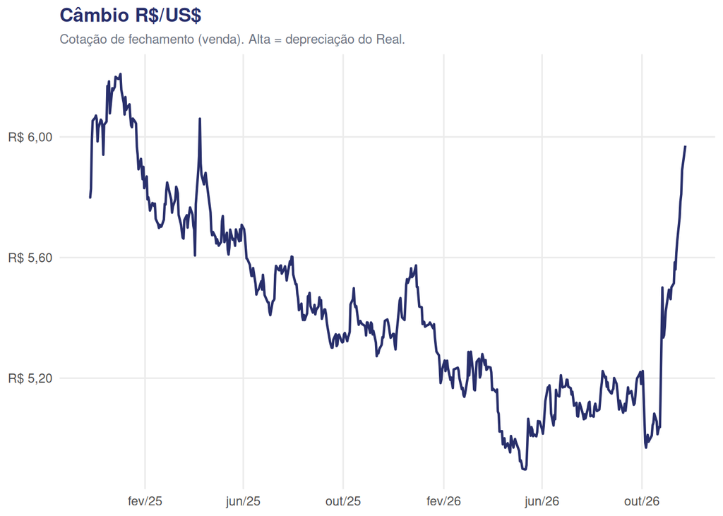

Câmbio R$/US$, cotação diária de fechamento (venda), últimos dois anos. Fonte: Banco Central, SGS 1.

### Taxa Selic

A meta da taxa Selic (SGS 432), definida pelo Copom, está em 13,75% a.a. na referência de 23/11/2026. As variações são reportadas em pontos percentuais (p.p.): 0,00 p.p. no mês, -1,25 p.p. no ano e -1,25 p.p. em doze meses. A meta ficou estável no mês, e o recuo aparece nos horizontes de ano e de doze meses.

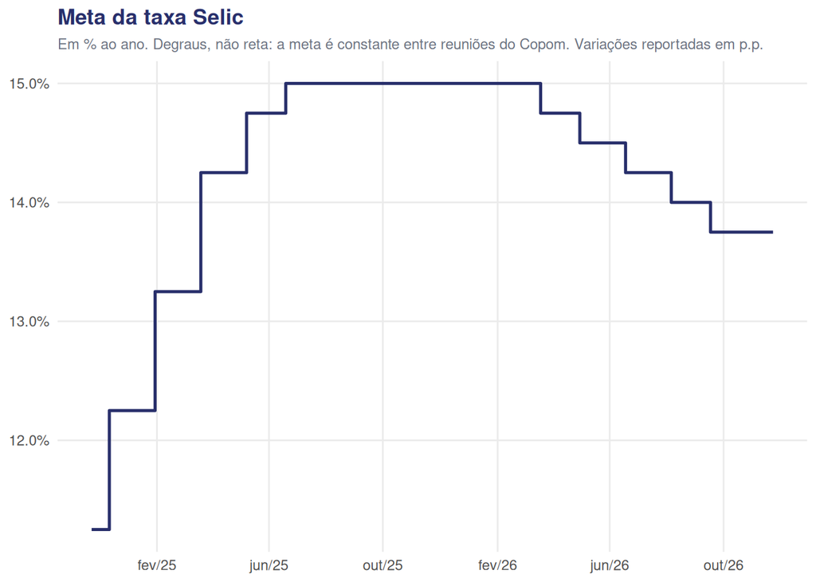

Meta da taxa Selic (% a.a.), em degraus, últimos dois anos. Fonte: Banco Central, SGS 432.

## Atividade

O Índice de Atividade Econômica do Banco Central (IBC-Br) tem como mês de referência mais recente 09/2026, defasado em relação à data deste boletim (2026-11-23).

Na comparação mensal, a série com ajuste sazonal (fonte: Banco Central, SGS 24364) apresenta variação de -0,25% em 09/2026 frente ao mês anterior, uma queda.

No horizonte de doze meses, a série original (fonte: Banco Central, SGS 24363), calculada por média de período, apresenta variação de 1,43%. No acumulado do ano, a mesma série original (SGS 24363), também por média de período, mostra variação de 1,39%. As leituras dessazonalizada (margem) e original (interanual) são reportadas separadamente, sem síntese entre elas.

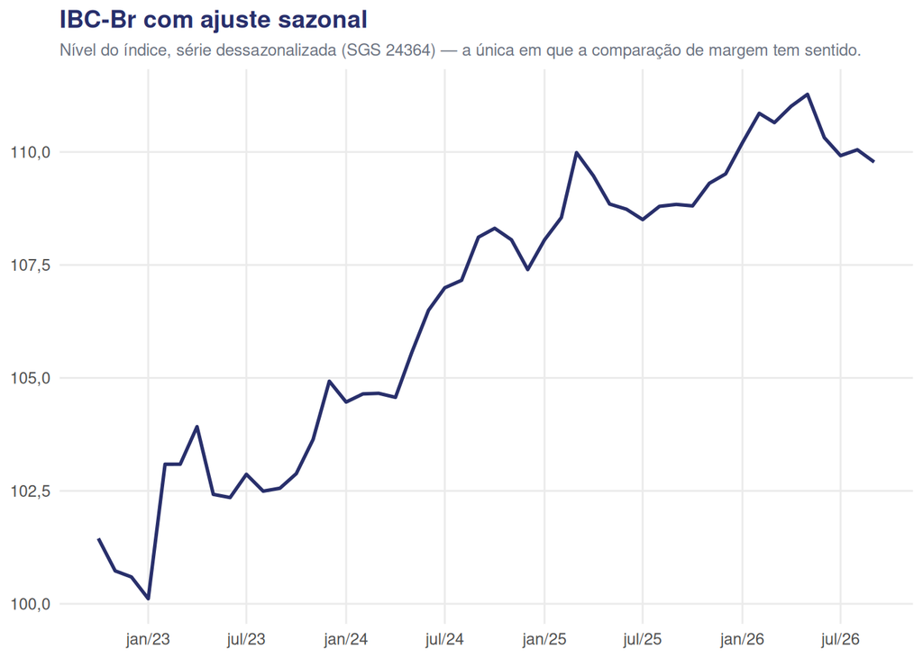

IBC-Br com ajuste sazonal, nível do índice, últimos 48 meses. Fonte: Banco Central, SGS 24364.

*Boletim elaborado com base nos dados disponíveis em 2026-11-23. Fontes primárias: Banco Central do Brasil, Sistema Gerenciador de Séries Temporais (SGS), via `rbcb::get_series`. Séries: IPCA mensal (SGS 433), câmbio R$/US$ (SGS 1), Selic meta (SGS 432), IBC-Br original (SGS 24363) e IBC-Br com ajuste sazonal (SGS 24364).*